# practitioner_def_newproc_allpde

### Benchmark

```
Fold done in: 1.48 s
Fold done in: 1.97 s
Fold done in: 1.25 s
Fold done in: 1.16 s
Fold done in: 1.24 s
```

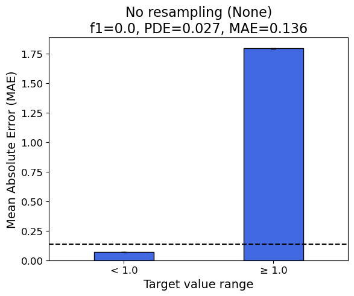

```
MAE: 0.13564762799106997
average computational time: 1.42 s
```

```python
# Empty list for storing results
pdes, f1s, maebins, maes, times = [], [], [], [], []

# Fivefold cross validation
kfold = KFold(n_splits=5, shuffle=True, random_state=42)

for train_index, test_index in kfold.split(X):
    df_train = df.reset_index(drop=True).loc[train_index,:].reset_index(drop=True)
    X_train, y_train = X.loc[train_index,:].reset_index(drop=True), y.loc[train_index].reset_index(drop=True)
    X_test, y_test = X.loc[test_index,:].reset_index(drop=True), y.loc[test_index].reset_index(drop=True)
    reg = PoissonRegressor(alpha=1e-4, solver="newton-cholesky")
    pde, f1, maebin, mae, y_pred, comp_time = implementBenchmark(df_train, X_train, y_train, X_test, y_test, reg) #Fit regressor and evaluate performance
    pdes.append(pde); f1s.append(f1); maebins.append(maebin); maes.append(mae); times.append(comp_time)
    print('Fold done in:',format(comp_time, '.2f'),'s')

# Average performance
pde, f1, maebin, mae, comp_time = np.mean(pdes), np.mean(f1s), np.mean(maebins, axis=0), np.mean(maes), np.mean(times)

# Standard error of the mean
pdeerr, f1err, maebinerr, maeerr, comp_timeerr = np.std(pdes)/np.sqrt(5), np.std(f1s)/np.sqrt(5), \
                            np.std(maebins, axis=0)/np.sqrt(5), np.std(maes)/np.sqrt(5), np.std(times)/np.sqrt(5)
# View performance
plotPerformance(maebin, maebinerr, f1, pde, mae, title='No resampling (None)')
print('average computational time:', format(comp_time, '.2f'),'s')

# Save performance results
CACHE = {}
CACHE['Benchmark'] = [pde, f1, maebin, mae, pdeerr, f1err, maebinerr, maeerr, comp_time, comp_timeerr]
```

### Poisson Random Undersampling (POI RU)

With this strategy, the normal domain is undersampled, while the rare domain is left untouched. The degree of undersampling can be specified as a percentage (float), or three automatic options may be used:

1. *balance*: samples are removed from the normal domain so that it is equal in size to the rare domain
2. *extreme*: samples are removed from the normal domain so that the ratio of sizes is reversed. If the normal domain was five times larger than the rare domain, samples are removed from the normal domain so that the rare domain is five times larger.
3. *average*: intermediate between balance and extreme.

We will determine the optimal degree of undersampling using a grid search. The best undersampling degree will be the one that yields the highest F1 score.

```
Fold done in: 0.12 s
Fold done in: 0.11 s
Fold done in: 0.12 s
Fold done in: 0.12 s
Fold done in: 0.10 s
Best parameters:
    under=balance
```

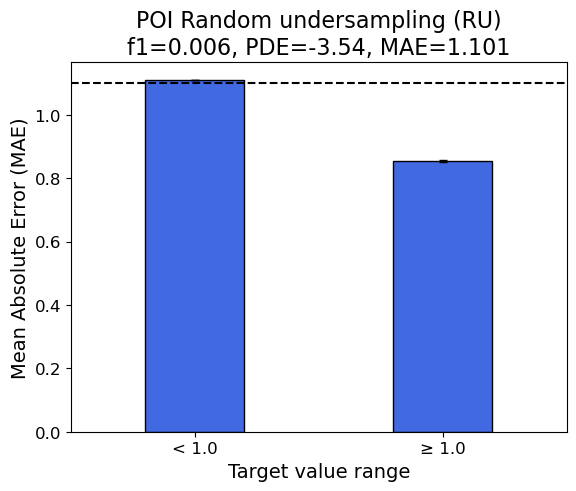

```
MAE: 1.1006709515744362
average computational time: 0.11 s
```

```python
# Degree of undersampling
unders = ['balance']

# Empty lists for storing results
pdestore, f1store, maebinstore, maestore, timestore = [], [], [], [], []
pdeerrstore, f1errstore, maebinerrstore, maeerrstore, timeerrstore = [], [], [], [], []

# Grid search
for under in unders:
    kfold = KFold(n_splits=5, shuffle=True, random_state=42)
    pdes, f1s, maebins, maes, times = [], [], [], [], []
    # Fivefold cross validation
    for train_index, test_index in kfold.split(X):
        X_train, y_train = X.loc[train_index,:].reset_index(drop=True), y.loc[train_index].reset_index(drop=True)
        X_test, y_test = X.loc[test_index,:].reset_index(drop=True), y.loc[test_index].reset_index(drop=True)
        # Resample training data (Random Undersampling)
        relevance = resreg.sigmoid_relevance(y_train, cl=None, ch=bins[0])
        X_train, y_train = resreg.random_undersample(X_train ,y_train, relevance,
                                    relevance_threshold=0.5, under=under, random_state=0)
        # Fit regressor and evaluate performance
        reg = PoissonRegressor(alpha=1e-4, solver="newton-cholesky")
        pde, f1, maebin, mae, y_pred, comp_time = implementML(X_train, y_train, X_test, y_test, reg)
        pdes.append(pde)
        f1s.append(f1)
        maebins.append(maebin)
        maes.append(mae)
        times.append(comp_time)
        print('Fold done in:',format(comp_time, '.2f'),'s')

    pde, f1, maebin, mae, comp_time = np.mean(pdes), np.mean(f1s), np.mean(maebins, axis=0), np.mean(maes), np.mean(times)
    pdeerr, f1err, maebinerr, maeerr, comp_timeerr = np.std(pdes)/np.sqrt(5), np.std(f1s)/np.sqrt(5), \
                                np.std(maebins, axis=0)/np.sqrt(5), np.std(maes)/np.sqrt(5), np.std(times)/np.sqrt(5)
    pdestore.append(pde); f1store.append(f1); maebinstore.append(maebin); maestore.append(mae), timestore.append(comp_time)
    pdeerrstore.append(pdeerr); f1errstore.append(f1err); maebinerrstore.append(maebinerr); maeerrstore.append(maeerr); timeerrstore.append(comp_timeerr)


# Determine the best undersampling degree
best = np.argsort(f1store)[-1] # Which is the best
print('''Best parameters:
    under={0}'''.format(unders[best]))
f1, pde, maebin, mae, comp_time = f1store[best], pdestore[best], maebinstore[best], maestore[best], timestore[best]
f1err, pdeerr, maebinerr, maeerr, comp_timeerr = f1errstore[best], pdeerrstore[best], maebinerrstore[best], maeerrstore[best], timeerrstore[best]

# Save results
CACHE['POI RU'] = [pde, f1, maebin, mae, pdeerr, f1err, maebinerr, maeerr, comp_time, comp_timeerr]

# Plot results
plotPerformance(maebin, maebinerr, f1, pde, mae, title='POI Random undersampling (RU)')
print('average computational time:', format(comp_time, '.2f'),'s')
```

### Poisson Random Oversampling (POI RO)

With this strategy, the normal domain is left untouched, while the rare domain is oversampled by duplication. The degree of oversampling can be specified as a percentage (float), or as *balance*, *extreme*, or *average*. We will determine the optimal oversampling degree using a grid search.

```
Fold done in: 2.41 s
Fold done in: 2.55 s
Fold done in: 2.16 s
Fold done in: 2.17 s
Fold done in: 1.94 s
Best parameters:
    over=balance
```

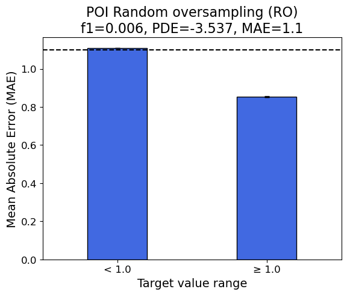

```
MAE: 1.0998634614655136
average computational time: 2.25 s
```

```python
# Degree of oversampling
overs = ['balance']

# Empty lists for storing results
pdestore, f1store, maebinstore, maestore, timestore = [], [], [], [], []
pdeerrstore, f1errstore, maebinerrstore, maeerrstore, timeerrstore = [], [], [], [], []

# Grid search
for over in overs:
    kfold = KFold(n_splits=5, shuffle=True, random_state=42)
    pdes, f1s, maebins, maes, times = [], [], [], [], []
    # Fivefold cross validation
    for train_index, test_index in kfold.split(X):
        X_train, y_train = X.loc[train_index,:].reset_index(drop=True), y.loc[train_index].reset_index(drop=True)
        X_test, y_test = X.loc[test_index,:].reset_index(drop=True), y.loc[test_index].reset_index(drop=True)

        # Resample training data (Random Oversampling)
        relevance = resreg.sigmoid_relevance(y_train, cl=None, ch=bins[0])
        X_train, y_train = resreg.random_oversample(X_train ,y_train, relevance,
                                    relevance_threshold=0.5, over=over, random_state=0)

        # Fit regressor and evaluate performance
        reg = PoissonRegressor(alpha=1e-4, solver="newton-cholesky")
        pde, f1, maebin, mae, y_pred, comp_time = implementML(X_train, y_train, X_test, y_test, reg)
        pdes.append(pde)
        f1s.append(f1)
        maebins.append(maebin)
        maes.append(mae)
        times.append(comp_time)
        print('Fold done in:',format(comp_time, '.2f'),'s')

    pde, f1, maebin, mae, comp_time = np.mean(pdes), np.mean(f1s), np.mean(maebins, axis=0), np.mean(maes), np.mean(times)
    pdeerr, f1err, maebinerr, maeerr, comp_timeerr = np.std(pdes)/np.sqrt(5), np.std(f1s)/np.sqrt(5), \
                                np.std(maebins, axis=0)/np.sqrt(5), np.std(maes)/np.sqrt(5), np.std(times)/np.sqrt(5)

    # Store grid search results
    pdestore.append(pde); f1store.append(f1); maebinstore.append(maebin); maestore.append(mae), timestore.append(comp_time)
    pdeerrstore.append(pdeerr); f1errstore.append(f1err); maebinerrstore.append(maebinerr); maeerrstore.append(maeerr); timeerrstore.append(comp_timeerr)

# Determine the best oversampling degree
best = np.argsort(f1store)[-1] # Which is the best
print('''Best parameters:
    over={0}'''.format(overs[best]))
f1, pde, maebin, mae, comp_time = f1store[best], pdestore[best], maebinstore[best], maestore[best], timestore[best]
f1err, pdeerr, maebinerr, maeerr, comp_timeerr = f1errstore[best], pdeerrstore[best], maebinerrstore[best], maeerrstore[best], timeerrstore[best]

# Save results
CACHE['POI RO'] = [pde, f1, maebin, mae, pdeerr, f1err, maebinerr, maeerr, comp_time, comp_timeerr]

# Plot results
plotPerformance(maebin, maebinerr, f1, pde, mae, title='POI Random oversampling (RO)')
print('average computational time:', format(comp_time, '.2f'),'s')
```

With SMOTER, the normal domain is undersampled, and the rare domain is oversampled. Oversampling is achieved via generating synthetic cases through interpolation rare values and a random selection of k-nearest neighbors. The user specifies the degree of oversampling and the number of nearest neighbors to select a candidate for interpolation.

```
Fold done in: 29.13 s
Fold done in: 31.72 s
Fold done in: 30.47 s
Fold done in: 32.79 s
Fold done in: 31.82 s
Best parameters:
    over=balance; k=5
```

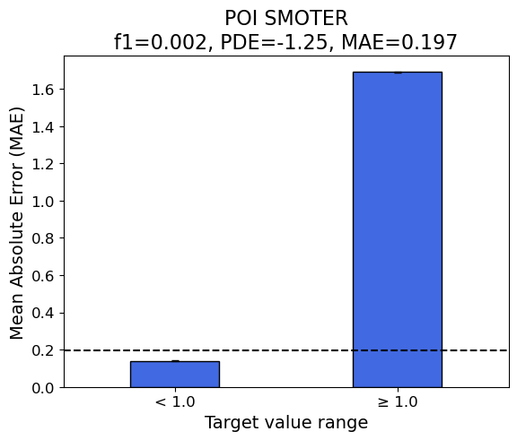

```
MAE: 0.19723228329262416
average computational time: 31.19 s
```

```python
# Parameters
overs = ['balance']
ks = [5] # nearest neighbors
params = list(itertools.product(overs, ks))

# Empty lists for storing results
pdestore, f1store, maebinstore, maestore, timestore = [], [], [], [], []
pdeerrstore, f1errstore, maebinerrstore, maeerrstore, timeerrstore = [], [], [], [], []

# Grid search
for over, k in params:
    kfold = KFold(n_splits=5, shuffle=True, random_state=42)
    pdes, f1s, maebins, maes, times = [], [], [], [], []

    # Fivefold cross validation
    for train_index, test_index in kfold.split(X):
        X_train, y_train = X.loc[train_index,:].reset_index(drop=True), y.loc[train_index].reset_index(drop=True)
        X_test, y_test = X.loc[test_index,:].reset_index(drop=True), y.loc[test_index].reset_index(drop=True)

        # Resample training data (SMOTER)
        relevance = resreg.sigmoid_relevance(y_train, cl=None, ch=bins[0])
        X_train, y_train = resreg.smoter(X_train, y_train, relevance,
                                relevance_threshold=0.5, k=k, over=over, random_state=0)

        # Fit regressor and evaluate performance
        reg = RandomForestRegressor(n_estimators=50, max_features=0.5, n_jobs=-1,
                                    random_state=0)
        pde, f1, maebin, mae, y_pred, comp_time = implementML(X_train, y_train, X_test, y_test, reg)
        pdes.append(pde)
        f1s.append(f1)
        maebins.append(maebin)
        maes.append(mae)
        times.append(comp_time)
        print('Fold done in:',format(comp_time, '.2f'),'s')

    pde, f1, maebin, mae, comp_time = np.mean(pdes), np.mean(f1s), np.mean(maebins, axis=0), np.mean(maes), np.mean(times)
    pdeerr, f1err, maebinerr, maeerr, comp_timeerr = np.std(pdes)/np.sqrt(5), np.std(f1s)/np.sqrt(5), \
                                np.std(maebins, axis=0)/np.sqrt(5), np.std(maes)/np.sqrt(5), np.std(times)/np.sqrt(5)

    # Store grid search results
    pdestore.append(pde); f1store.append(f1); maebinstore.append(maebin); maestore.append(mae), timestore.append(comp_time)
    pdeerrstore.append(pdeerr); f1errstore.append(f1err); maebinerrstore.append(maebinerr); maeerrstore.append(maeerr); timeerrstore.append(comp_timeerr)

# Determine the best parameters
best = np.argsort(f1store)[-1] # Which is the best
print('''Best parameters:
    over={0}; k={1}'''.format(params[best][0], params[best][1]))
f1, pde, maebin, mae, comp_time = f1store[best], pdestore[best], maebinstore[best], maestore[best], timestore[best]
f1err, pdeerr, maebinerr, maeerr, comp_timeerr = f1errstore[best], pdeerrstore[best], maebinerrstore[best], maeerrstore[best], timeerrstore[best]

# Save results
CACHE['POI SMOTER'] = [pde, f1, maebin, mae, pdeerr, f1err, maebinerr, maeerr, comp_time, comp_timeerr]

# Plot results
plotPerformance(maebin, maebinerr, f1, pde, mae, title='POI SMOTER')
print('average computational time:', format(comp_time, '.2f'),'s')
```

### Poisson Gaussian Noise (POI GN)

With this strategy, the normal domain is undersampled and the rare domain is oversampled by generating synthetic cases. Synthetic cases are generated by adding Gaussian noise to the features (X) and to the target values (y) of rare domain instances. The user specifies the degree of oversampling and the amount of noise (*delta*) to be added.

```
Fold done in: 1.25 s
Fold done in: 1.21 s
Fold done in: 1.02 s
Fold done in: 1.06 s
Fold done in: 1.23 s
Best parameters:
    over=balance; delta=0.1
```

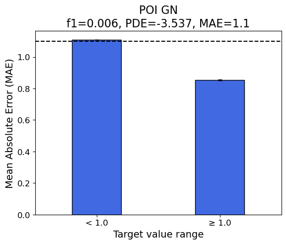

```
MAE: 1.099773516918121
average computational time: 1.16 s
```

```python
# Parameters
overs = ['balance']
deltas = [0.1] # amount of Gaussian noise
params = list(itertools.product(overs, deltas))

# Empty lists for storing results
pdestore, f1store, maebinstore, maestore, timestore = [], [], [], [], []
pdeerrstore, f1errstore, maebinerrstore, maeerrstore, timeerrstore = [], [], [], [], []

# Grid search
for over, delta in params:
    kfold = KFold(n_splits=5, shuffle=True, random_state=42)
    pdes, f1s, maebins, maes, times = [], [], [], [], []

    # Fivefold cross validation
    for train_index, test_index in kfold.split(X):
        X_train, y_train = X.loc[train_index,:].reset_index(drop=True), y.loc[train_index].reset_index(drop=True)
        X_test, y_test = X.loc[test_index,:].reset_index(drop=True), y.loc[test_index].reset_index(drop=True)

        # Resample training data (Gaussian Noise)
        relevance = resreg.sigmoid_relevance(y_train, cl=None, ch=bins[0])
        X_train, y_train = resreg.gaussian_noise(X_train, y_train, relevance,
                                relevance_threshold=0.5, delta=delta, over=over,
                                random_state=0)

        # Fit regressor and evaluate performance
        reg = PoissonRegressor(alpha=1e-4, solver="newton-cholesky")
        pde, f1, maebin, mae, y_pred, comp_time = implementML(X_train, y_train, X_test, y_test, reg)
        pdes.append(pde)
        f1s.append(f1)
        maebins.append(maebin)
        maes.append(mae)
        times.append(comp_time)
        print('Fold done in:',format(comp_time, '.2f'),'s')

    pde, f1, maebin, mae, comp_time = np.mean(pdes), np.mean(f1s), np.mean(maebins, axis=0), np.mean(maes), np.mean(times)
    pdeerr, f1err, maebinerr, maeerr, comp_timeerr = np.std(pdes)/np.sqrt(5), np.std(f1s)/np.sqrt(5), \
                                np.std(maebins, axis=0)/np.sqrt(5), np.std(maes)/np.sqrt(5), np.std(times)/np.sqrt(5)

    # Store grid search results
    pdestore.append(pde); f1store.append(f1); maebinstore.append(maebin); maestore.append(mae), timestore.append(comp_time)
    pdeerrstore.append(pdeerr); f1errstore.append(f1err); maebinerrstore.append(maebinerr); maeerrstore.append(maeerr); timeerrstore.append(comp_timeerr)


# Determine the best parameters
best = np.argsort(f1store)[-1] # Which is the best
print('''Best parameters:
    over={0}; delta={1}'''.format(params[best][0], params[best][1]))
f1, pde, maebin, mae, comp_time = f1store[best], pdestore[best], maebinstore[best], maestore[best], timestore[best]
f1err, pdeerr, maebinerr, maeerr, comp_timeerr = f1errstore[best], pdeerrstore[best], maebinerrstore[best], maeerrstore[best], timeerrstore[best]

# Save results
CACHE['POI GN'] = [pde, f1, maebin, mae, pdeerr, f1err, maebinerr, maeerr, comp_time, comp_timeerr]

# Plot results
plotPerformance(maebin, maebinerr, f1, pde, mae, title='POI GN')
print('average computational time:', format(comp_time, '.2f'),'s')
```

### Poisson weighted relevance-based combination strategy (POI WERCS)

With this strategy, target values are not split into rare and normal domains. Rather, relevance values are used as weights (probabilities) to select samples for undersampling and oversampling. Instances with high relevance values have higher probabilties of being selected for oversampling and lower probabilities of being selected for undersampling. The user specifies the percentage of oversampling and undersampling (float). Rather than duplicating samples in the oversampling step, Gaussian noise can be added to the samples by specifying *noise*=True as well as the amount of noise (*delta*).

```
Fold done in: 1.02 s
Fold done in: 1.13 s
Fold done in: 0.96 s
Fold done in: 0.98 s
Fold done in: 1.16 s
Best parameters:
    over=1.0; under=0.75; noise=False; delta=None
```

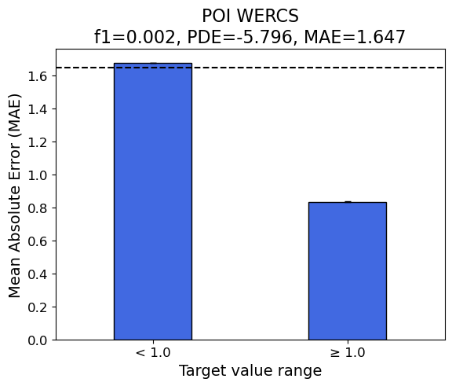

```
MAE: 1.6466155154154336
average computational time: 1.05 s
```

```python
# Parameters
overs = [1.0] # percent of samples added
unders = [0.75] # percent of samples removed
noises = [False] # Whether to add Gaussian noise to oversampled data
params = list(itertools.product(overs, unders, noises))

# Empty lists for storing results
pdestore, f1store, maebinstore, maestore, timestore = [], [], [], [], []
pdeerrstore, f1errstore, maebinerrstore, maerrstore = [], [], [], []

# Grid search
for param in params:
    if len(param)==4:
        over, under, noise, delta = param
    else:
        over, under, noise = param
        delta = None
    kfold = KFold(n_splits=5, shuffle=True, random_state=42)
    pdes, f1s, maebins, maes, times = [], [], [], [], []

    # Fivefold cross validation
    for train_index, test_index in kfold.split(X):
        X_train, y_train = X.loc[train_index,:].reset_index(drop=True), y.loc[train_index].reset_index(drop=True)
        X_test, y_test = X.loc[test_index,:].reset_index(drop=True), y.loc[test_index].reset_index(drop=True)

        # Resample training data (WERCS)
        relevance = resreg.sigmoid_relevance(y_train, cl=None, ch=bins[0])
        X_train, y_train = resreg.wercs(X_train, y_train, relevance, over=over,
                              under=under, noise=noise, delta=delta, random_state=0)

        # Fit regressor and evaluate performance
        reg = PoissonRegressor(alpha=1e-4, solver="newton-cholesky")
        pde, f1, maebin, mae, y_pred, comp_time = implementML(X_train, y_train, X_test, y_test, reg)
        pdes.append(pde)
        f1s.append(f1)
        maebins.append(maebin)
        maes.append(mae)
        times.append(comp_time)
        print('Fold done in:',format(comp_time, '.2f'),'s')

    pde, f1, maebin, mae, comp_time = np.mean(pdes), np.mean(f1s), np.mean(maebins, axis=0), np.mean(maes), np.mean(times)
    pdeerr, f1err, maebinerr, maeerr, comp_timeerr = np.std(pdes)/np.sqrt(5), np.std(f1s)/np.sqrt(5), \
                                np.std(maebins, axis=0)/np.sqrt(5), np.std(maes)/np.sqrt(5), np.std(times)/np.sqrt(5)

    # Store grid search results
    pdestore.append(pde); f1store.append(f1); maebinstore.append(maebin); maestore.append(mae), timestore.append(comp_time)
    pdeerrstore.append(pdeerr); f1errstore.append(f1err); maebinerrstore.append(maebinerr); maeerrstore.append(maeerr); timeerrstore.append(comp_timeerr)

# Determine the best parameters
best = np.argsort(f1store)[-1] # Which is the best
bestparam = params[best]
if len(param)==4:
    over, under, noise, delta= param
else:
    over, under, noise = param
    delta = None
print(f'''Best parameters:
    over={over}; under={under}; noise={noise}; delta={delta}''')
f1, pde, maebin, mae, comp_time = f1store[best], pdestore[best], maebinstore[best], maestore[best], timestore[best]
f1err, pdeerr, maebinerr, maeerr, comp_timeerr = f1errstore[best], pdeerrstore[best], maebinerrstore[best], maeerrstore[best], timeerrstore[best]

# Save results
CACHE['POI WERCS'] = [pde, f1, maebin, mae, pdeerr, f1err, maebinerr, maeerr, comp_time, comp_timeerr]

# Plot results
plotPerformance(maebin, maebinerr, f1, pde, mae, title='POI WERCS')
print('average computational time:', format(comp_time, '.2f'),'s')
```

### RF without resampling (NONE)

```
Fold done in: 16.41 s
Fold done in: 16.50 s
Fold done in: 16.71 s
Fold done in: 17.11 s
Fold done in: 16.66 s
```

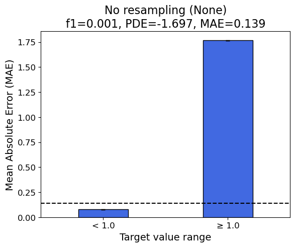

```
MAE: 0.13885286860488816
average computational time: 16.68 s
```

```python
# Empty list for storing results
pdes, f1s, maebins, maes, times = [], [], [], [], []

# Fivefold cross validation
kfold = KFold(n_splits=5, shuffle=True, random_state=42)

for train_index, test_index in kfold.split(X):
    X_train, y_train = X.loc[train_index,:].reset_index(drop=True), y.loc[train_index].reset_index(drop=True)
    X_test, y_test = X.loc[test_index,:].reset_index(drop=True), y.loc[test_index].reset_index(drop=True)
    reg = RandomForestRegressor(n_estimators=50, max_features=0.5, n_jobs=-1, random_state=0)
    pde, f1, maebin, mae, y_pred, comp_time = implementML(X_train, y_train, X_test, y_test, reg) #Fit regressor and evaluate performance
    pdes.append(pde); f1s.append(f1); maebins.append(maebin); maes.append(mae); times.append(comp_time)
    print('Fold done in:',format(comp_time, '.2f'),'s')

# Average performance
pde, f1, maebin, mae, comp_time = np.mean(pdes), np.mean(f1s), np.mean(maebins, axis=0), np.mean(maes), np.mean(times)

# Standard error of the mean
pdeerr, f1err, maebinerr, maeerr, comp_timeerr = np.std(pdes)/np.sqrt(5), np.std(f1s)/np.sqrt(5), \
                            np.std(maebins, axis=0)/np.sqrt(5), np.std(maes)/np.sqrt(5), np.std(times)/np.sqrt(5)
# View performance
plotPerformance(maebin, maebinerr, f1, pde, mae, title='No resampling (None)')
print('average computational time:', format(comp_time, '.2f'),'s')

# Save performance results
CACHE['RF None'] = [pde, f1, maebin, mae, pdeerr, f1err, maebinerr, maeerr, comp_time, comp_timeerr]
```

### RF Random undersampling (RU)

```
Fold done in: 0.85 s
Fold done in: 0.84 s
Fold done in: 0.81 s
Fold done in: 0.80 s
Fold done in: 0.92 s
Best parameters:
    under=balance
```

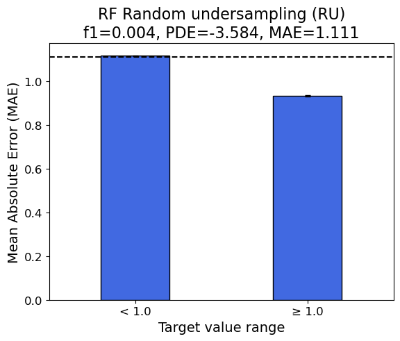

```
MAE: 1.1107036328334796
average computational time: 0.84 s
```

```python
# Degree of undersampling
unders = ['balance']

# Empty lists for storing results
pdestore, f1store, maebinstore, maestore, timestore = [], [], [], [], []
pdeerrstore, f1errstore, maebinerrstore, maeerrstore, timeerrstore = [], [], [], [], []

# Grid search
for under in unders:
    kfold = KFold(n_splits=5, shuffle=True, random_state=42)
    pdes, f1s, maebins, maes, times = [], [], [], [], []
    # Fivefold cross validation
    for train_index, test_index in kfold.split(X):
        X_train, y_train = X.loc[train_index,:].reset_index(drop=True), y.loc[train_index].reset_index(drop=True)
        X_test, y_test = X.loc[test_index,:].reset_index(drop=True), y.loc[test_index].reset_index(drop=True)
        # Resample training data (Random Undersampling)
        relevance = resreg.sigmoid_relevance(y_train, cl=None, ch=bins[0])
        X_train, y_train = resreg.random_undersample(X_train ,y_train, relevance,
                                    relevance_threshold=0.5, under=under, random_state=0)
        # Fit regressor and evaluate performance
        reg = RandomForestRegressor(n_estimators=50, max_features=0.5, n_jobs=-1,
                                    random_state=0)
        pde, f1, maebin, mae, y_pred, comp_time = implementML(X_train, y_train, X_test, y_test, reg)
        pdes.append(pde)
        f1s.append(f1)
        maebins.append(maebin)
        maes.append(mae)
        times.append(comp_time)
        print('Fold done in:',format(comp_time, '.2f'),'s')

    pde, f1, maebin, mae, comp_time = np.mean(pdes), np.mean(f1s), np.mean(maebins, axis=0), np.mean(maes), np.mean(times)
    pdeerr, f1err, maebinerr, maeerr, comp_timeerr = np.std(pdes)/np.sqrt(5), np.std(f1s)/np.sqrt(5), \
                                np.std(maebins, axis=0)/np.sqrt(5), np.std(maes)/np.sqrt(5), np.std(times)/np.sqrt(5)
    pdestore.append(pde); f1store.append(f1); maebinstore.append(maebin); maestore.append(mae), timestore.append(comp_time)
    pdeerrstore.append(pdeerr); f1errstore.append(f1err); maebinerrstore.append(maebinerr); maeerrstore.append(maeerr); timeerrstore.append(comp_timeerr)


# Determine the best undersampling degree
best = np.argsort(f1store)[-1] # Which is the best
print('''Best parameters:
    under={0}'''.format(unders[best]))
f1, pde, maebin, mae, comp_time = f1store[best], pdestore[best], maebinstore[best], maestore[best], timestore[best]
f1err, pdeerr, maebinerr, maeerr, comp_timeerr = f1errstore[best], pdeerrstore[best], maebinerrstore[best], maeerrstore[best], timeerrstore[best]

# Save results
CACHE['RF RU'] = [pde, f1, maebin, mae, pdeerr, f1err, maebinerr, maeerr, comp_time, comp_timeerr]

# Plot results
plotPerformance(maebin, maebinerr, f1, pde, mae, title='RF Random undersampling (RU)')
print('average computational time:', format(comp_time, '.2f'),'s')
```

### RF SMOTER

```
Fold done in: 48.58 s
Fold done in: 51.75 s
Fold done in: 50.16 s
Fold done in: 53.58 s
Fold done in: 55.64 s
Best parameters:
    over=average; k=10
```

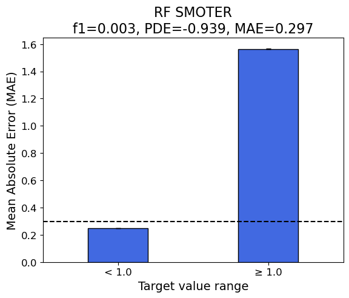

```
MAE: 0.29706685251020987
average computational time: 51.94 s
```

```python
# Parameters
overs = ['average']
ks = [10] # nearest neighbors
params = list(itertools.product(overs, ks))

# Empty lists for storing results
pdestore, f1store, maebinstore, maestore, timestore = [], [], [], [], []
pdeerrstore, f1errstore, maebinerrstore, maeerrstore, timeerrstore = [], [], [], [], []

# Grid search
for over, k in params:
    kfold = KFold(n_splits=5, shuffle=True, random_state=42)
    pdes, f1s, maebins, maes, times = [], [], [], [], []

    # Fivefold cross validation
    for train_index, test_index in kfold.split(X):
        X_train, y_train = X.loc[train_index,:].reset_index(drop=True), y.loc[train_index].reset_index(drop=True)
        X_test, y_test = X.loc[test_index,:].reset_index(drop=True), y.loc[test_index].reset_index(drop=True)

        # Resample training data (SMOTER)
        relevance = resreg.sigmoid_relevance(y_train, cl=None, ch=bins[0])
        X_train, y_train = resreg.smoter(X_train, y_train, relevance,
                                relevance_threshold=0.5, k=k, over=over, random_state=0)

        # Fit regressor and evaluate performance
        reg = RandomForestRegressor(n_estimators=50, max_features=0.5, n_jobs=-1,
                                    random_state=0)
        pde, f1, maebin, mae, y_pred, comp_time = implementML(X_train, y_train, X_test, y_test, reg)
        pdes.append(pde)
        f1s.append(f1)
        maebins.append(maebin)
        maes.append(mae)
        times.append(comp_time)
        print('Fold done in:',format(comp_time, '.2f'),'s')

    pde, f1, maebin, mae, comp_time = np.mean(pdes), np.mean(f1s), np.mean(maebins, axis=0), np.mean(maes), np.mean(times)
    pdeerr, f1err, maebinerr, maeerr, comp_timeerr = np.std(pdes)/np.sqrt(5), np.std(f1s)/np.sqrt(5), \
                                np.std(maebins, axis=0)/np.sqrt(5), np.std(maes)/np.sqrt(5), np.std(times)/np.sqrt(5)

    # Store grid search results
    pdestore.append(pde); f1store.append(f1); maebinstore.append(maebin); maestore.append(mae), timestore.append(comp_time)
    pdeerrstore.append(pdeerr); f1errstore.append(f1err); maebinerrstore.append(maebinerr); maeerrstore.append(maeerr); timeerrstore.append(comp_timeerr)

# Determine the best parameters
best = np.argsort(f1store)[-1] # Which is the best
print('''Best parameters:
    over={0}; k={1}'''.format(params[best][0], params[best][1]))
f1, pde, maebin, mae, comp_time = f1store[best], pdestore[best], maebinstore[best], maestore[best], timestore[best]
f1err, pdeerr, maebinerr, maeerr, comp_timeerr = f1errstore[best], pdeerrstore[best], maebinerrstore[best], maeerrstore[best], timeerrstore[best]

# Save results
CACHE['RF SMOTER'] = [pde, f1, maebin, mae, pdeerr, f1err, maebinerr, maeerr, comp_time, comp_timeerr]

# Plot results
plotPerformance(maebin, maebinerr, f1, pde, mae, title='RF SMOTER')
print('average computational time:', format(comp_time, '.2f'),'s')
```

### RF WERCS

```
Fold done in: 105.75 s
Fold done in: 107.34 s
Fold done in: 126.20 s
Fold done in: 119.51 s
Fold done in: 136.68 s
Best parameters:
    over=1.0; under=0.75; noise=True; delta=0.5
```

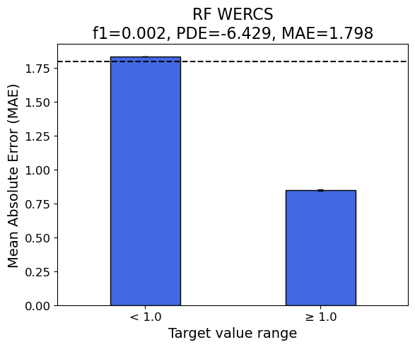

```
MAE: 1.7980360870416852
average computational time: 119.10 s
```

```python
# Parameters
overs = [1.0] # percent of samples added
unders = [0.75] # percent of samples removed
noises = [True] # Whether to add Gaussian noise to oversampled data
deltas = [0.5] # amount of Gaussian noise
params = list(itertools.product(overs, unders, [noises[0]], deltas))

# Empty lists for storing results
pdestore, f1store, maebinstore, maestore, timestore = [], [], [], [], []
pdeerrstore, f1errstore, maebinerrstore, maerrstore = [], [], [], []

# Grid search
for param in params:
    if len(param)==4:
        over, under, noise, delta = param
    else:
        over, under, noise = param
        delta = None
    kfold = KFold(n_splits=5, shuffle=True, random_state=42)
    pdes, f1s, maebins, maes, times = [], [], [], [], []

    # Fivefold cross validation
    for train_index, test_index in kfold.split(X):
        X_train, y_train = X.loc[train_index,:].reset_index(drop=True), y.loc[train_index].reset_index(drop=True)
        X_test, y_test = X.loc[test_index,:].reset_index(drop=True), y.loc[test_index].reset_index(drop=True)

        # Resample training data (WERCS)
        relevance = resreg.sigmoid_relevance(y_train, cl=None, ch=bins[0])
        X_train, y_train = resreg.wercs(X_train, y_train, relevance, over=over,
                              under=under, noise=noise, delta=delta, random_state=0)

        # Fit regressor and evaluate performance
        reg = RandomForestRegressor(n_estimators=50, max_features=0.5, n_jobs=-1,
                                    random_state=0)
        pde, f1, maebin, mae, y_pred, comp_time = implementML(X_train, y_train, X_test, y_test, reg)
        pdes.append(pde)
        f1s.append(f1)
        maebins.append(maebin)
        maes.append(mae)
        times.append(comp_time)
        print('Fold done in:',format(comp_time, '.2f'),'s')

    pde, f1, maebin, mae, comp_time = np.mean(pdes), np.mean(f1s), np.mean(maebins, axis=0), np.mean(maes), np.mean(times)
    pdeerr, f1err, maebinerr, maeerr, comp_timeerr = np.std(pdes)/np.sqrt(5), np.std(f1s)/np.sqrt(5), \
                                np.std(maebins, axis=0)/np.sqrt(5), np.std(maes)/np.sqrt(5), np.std(times)/np.sqrt(5)

    # Store grid search results
    pdestore.append(pde); f1store.append(f1); maebinstore.append(maebin); maestore.append(mae), timestore.append(comp_time)
    pdeerrstore.append(pdeerr); f1errstore.append(f1err); maebinerrstore.append(maebinerr); maeerrstore.append(maeerr); timeerrstore.append(comp_timeerr)


# Determine the best parameters
best = np.argsort(f1store)[-1] # Which is the best
bestparam = params[best]
if len(param)==4:
    over, under, noise, delta= param
else:
    over, under, noise = param
    delta = None
print(f'''Best parameters:
    over={over}; under={under}; noise={noise}; delta={delta}''')
f1, pde, maebin, mae, comp_time = f1store[best], pdestore[best], maebinstore[best], maestore[best], timestore[best]
f1err, pdeerr, maebinerr, maeerr, comp_timeerr = f1errstore[best], pdeerrstore[best], maebinerrstore[best], maeerrstore[best], timeerrstore[best]

# Save results
CACHE['RF WERCS'] = [pde, f1, maebin, mae, pdeerr, f1err, maebinerr, maeerr, comp_time, comp_timeerr]

# Plot results
plotPerformance(maebin, maebinerr, f1, pde, mae, title='RF WERCS')
print('average computational time:', format(comp_time, '.2f'),'s')
```

### Plot performance of all resampling methods

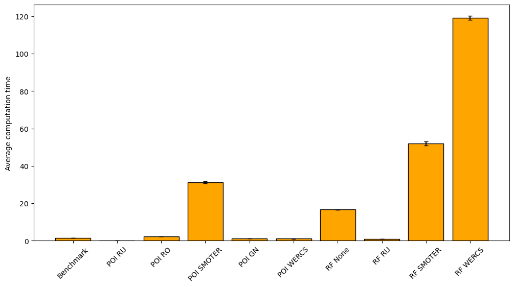

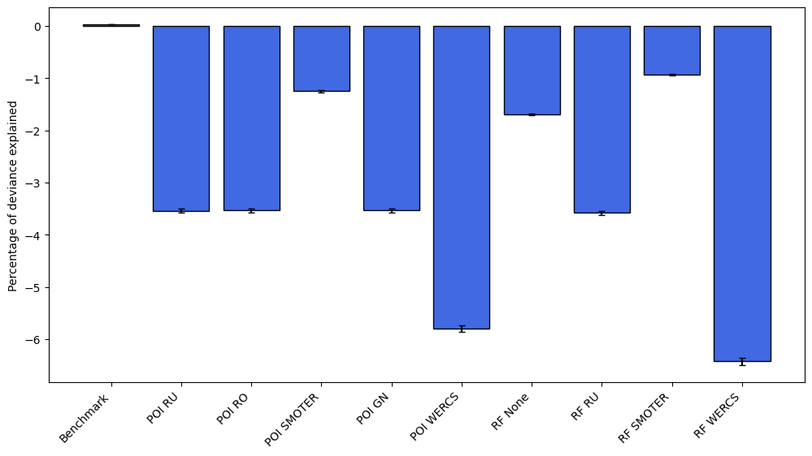

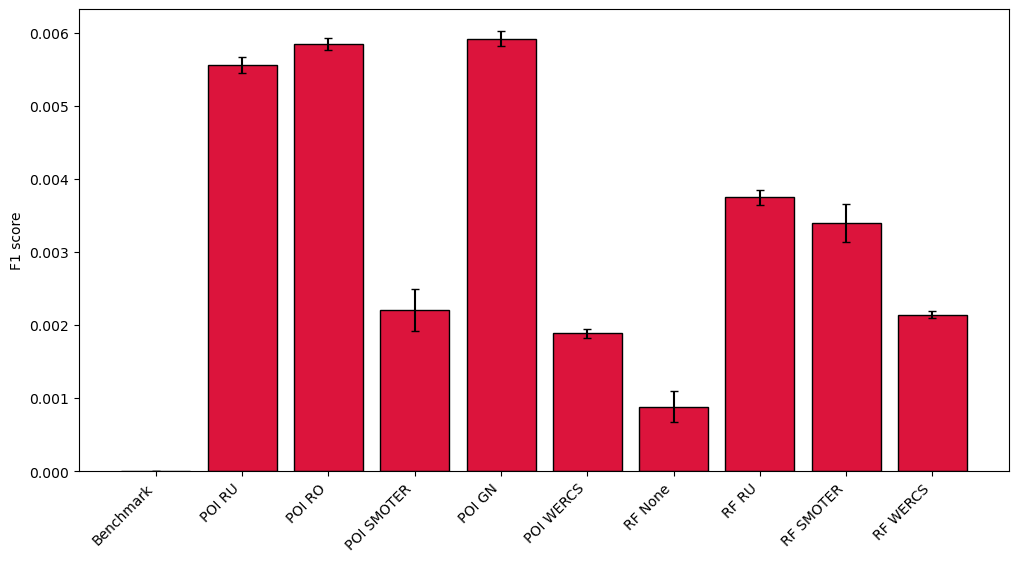

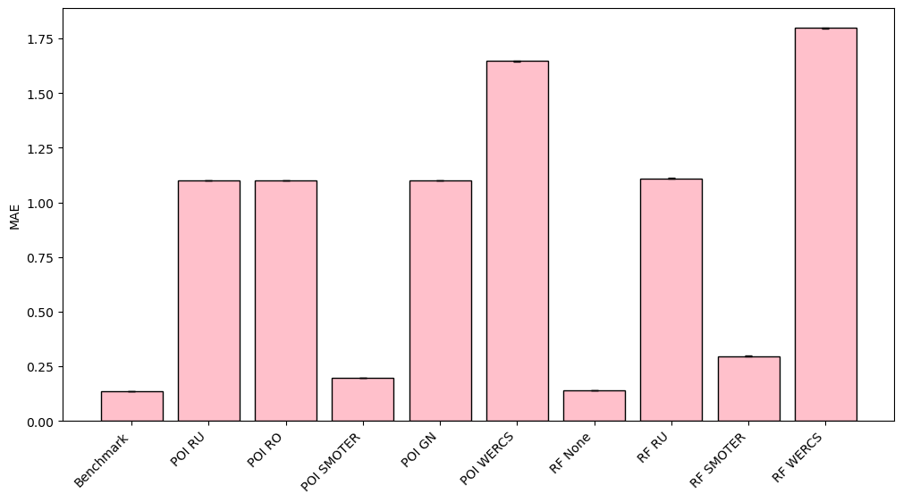

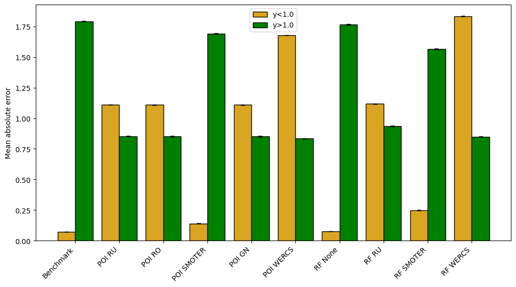

```python
# Data from CACHE
pdes = [val[0] for val in CACHE.values()]
pdeerrs = [val[4] for val in CACHE.values()]
f1s = [val[1] for val in CACHE.values()]
f1errs = [val[5] for val in CACHE.values()]
maebins = np.asarray([val[2] for val in CACHE.values()])
maebinerrs = np.asarray([val[6] for val in CACHE.values()])
maes = [val[3] for val in CACHE.values()]
maeerrs = [val[7] for val in CACHE.values()]
times = [val[8] for val in CACHE.values()]
timeerrs = [val[9] for val in CACHE.values()]
keys = CACHE.keys()

# Plot time
plt.figure(figsize=(12,6))
plt.bar(range(len(keys)), times, yerr=timeerrs, capsize=3, color='orange',
       linewidth=1, edgecolor='black')
_ = plt.xticks(range(len(keys)), keys, rotation=45)
plt.ylabel('Average computation time')
plt.show()

# Plot pde
plt.figure(figsize=(12,6))
plt.bar(range(len(keys)), pdes, yerr=pdeerrs, capsize=3, color='royalblue',
       linewidth=1, edgecolor='black', )
_ = plt.xticks(range(len(keys)), keys, rotation=45, ha='right')
plt.ylabel('Percentage of deviance explained')
plt.show()

# Plot F1
plt.figure(figsize=(12,6))
plt.bar(range(len(keys)), f1s, yerr=f1errs, capsize=3, color='crimson',
       linewidth=1, edgecolor='black')
_ = plt.xticks(range(len(keys)), keys, rotation=45, ha='right')
plt.ylabel('F1 score')
plt.show()

# Plot MAE
plt.figure(figsize=(12,6))
plt.bar(range(len(keys)), maes, yerr=maeerrs, capsize=3, color='pink',
       linewidth=1, edgecolor='black')
_ = plt.xticks(range(len(keys)), keys, rotation=45, ha='right')
plt.ylabel('MAE')
plt.show()

# Plot MAE over bins
plt.figure(figsize=(12,6))
plt.bar(np.arange(len(keys))-0.2, maebins[:,0], width=0.4, yerr=maebinerrs[:,0],
       capsize=3, color='goldenrod', linewidth=1, edgecolor='black', label='y<1.0')
plt.bar(np.arange(len(keys))+0.2, maebins[:,1], width=0.4, yerr=maebinerrs[:,1],
       capsize=3, color='green', linewidth=1, edgecolor='black', label='y>1.0')
_ = plt.xticks(range(len(keys)), keys, rotation=45, ha='right')
plt.ylabel('Mean absolute error')
plt.legend()
plt.show()
```

## XG-Boost

### XGB Without resampling (NONE)

```
Fold done in: 2.53 s
Fold done in: 2.59 s
Fold done in: 2.68 s
Fold done in: 2.51 s
Fold done in: 2.56 s
```

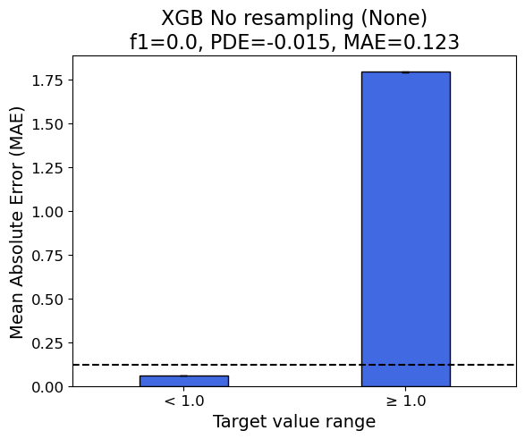

```
MAE: 0.12326412190735059
average computational time: 2.58 s
```

```python
# Empty list for storing results
pdes, f1s, maebins, maes, times = [], [], [], [], []

# Fivefold cross validation
kfold = KFold(n_splits=5, shuffle=True, random_state=42)

for train_index, test_index in kfold.split(X):
    X_train, y_train = X.loc[train_index,:].reset_index(drop=True), y.loc[train_index].reset_index(drop=True)
    X_test, y_test = X.loc[test_index,:].reset_index(drop=True), y.loc[test_index].reset_index(drop=True)
    reg = xgb.XGBRegressor(objective='reg:tweedie', tweedie_variance_power=1.8)
    pde, f1, maebin, mae, y_pred, comp_time = implementML(X_train, y_train, X_test, y_test, reg) #Fit regressor and evaluate performance
    pdes.append(pde); f1s.append(f1); maebins.append(maebin); maes.append(mae); times.append(comp_time)
    print('Fold done in:',format(comp_time, '.2f'),'s')

# Average performance
pde, f1, maebin, mae, comp_time = np.mean(pdes), np.mean(f1s), np.mean(maebins, axis=0), np.mean(maes), np.mean(times)
# Standard error of the mean
pdeerr, f1err, maebinerr, maeerr, comp_timeerr = np.std(pdes)/np.sqrt(5), np.std(f1s)/np.sqrt(5), \
                            np.std(maebins, axis=0)/np.sqrt(5), np.std(maes)/np.sqrt(5), np.std(times)/np.sqrt(5)
# View performance
plotPerformance(maebin, maebinerr, f1, pde, mae, title='XGB No resampling (None)')
print('average computational time:', format(comp_time, '.2f'),'s')

# Save performance results
CACHE['XGB None'] = [pde, f1, maebin, mae, pdeerr, f1err, maebinerr, maeerr, comp_time, comp_timeerr]
```

### XGB Random undersampling (RU)

```
Fold done in: 0.23 s
Fold done in: 0.21 s
Fold done in: 0.23 s
Fold done in: 0.23 s
Fold done in: 0.23 s
Best parameters:
    under=balance
```

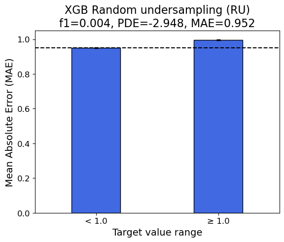

```
MAE: 0.9520387501181113
average computational time: 0.22 s
```

```python
# Degree of undersampling
unders = ['balance']

# Empty lists for storing results
pdestore, f1store, maebinstore, maestore, timestore = [], [], [], [], []
pdeerrstore, f1errstore, maebinerrstore, maeerrstore, timeerrstore = [], [], [], [], []

# Grid search
for under in unders:
    kfold = KFold(n_splits=5, shuffle=True, random_state=42)
    pdes, f1s, maebins, maes, times = [], [], [], [], []
    # Fivefold cross validation
    for train_index, test_index in kfold.split(X):
        X_train, y_train = X.loc[train_index,:].reset_index(drop=True), y.loc[train_index].reset_index(drop=True)
        X_test, y_test = X.loc[test_index,:].reset_index(drop=True), y.loc[test_index].reset_index(drop=True)
        # Resample training data (Random Undersampling)
        relevance = resreg.sigmoid_relevance(y_train, cl=None, ch=bins[0])
        X_train, y_train = resreg.random_undersample(X_train ,y_train, relevance,
                                    relevance_threshold=0.5, under=under, random_state=0)
        # Fit regressor and evaluate performance
        reg = xgb.XGBRegressor(objective='reg:tweedie', tweedie_variance_power=1.8)
        pde, f1, maebin, mae, y_pred, comp_time = implementML(X_train, y_train, X_test, y_test, reg)
        pdes.append(pde)
        f1s.append(f1)
        maebins.append(maebin)
        maes.append(mae)
        times.append(comp_time)
        print('Fold done in:',format(comp_time, '.2f'),'s')

    pde, f1, maebin, mae, comp_time = np.mean(pdes), np.mean(f1s), np.mean(maebins, axis=0), np.mean(maes), np.mean(times)
    pdeerr, f1err, maebinerr, maeerr, comp_timeerr = np.std(pdes)/np.sqrt(5), np.std(f1s)/np.sqrt(5), \
                                np.std(maebins, axis=0)/np.sqrt(5), np.std(maes)/np.sqrt(5), np.std(times)/np.sqrt(5)
    pdestore.append(pde); f1store.append(f1); maebinstore.append(maebin); maestore.append(mae), timestore.append(comp_time)
    pdeerrstore.append(pdeerr); f1errstore.append(f1err); maebinerrstore.append(maebinerr); maeerrstore.append(maeerr); timeerrstore.append(comp_timeerr)

# Determine the best undersampling degree
best = np.argsort(f1store)[-1] # Which is the best
print('''Best parameters:
    under={0}'''.format(unders[best]))
f1, pde, maebin, mae, comp_time = f1store[best], pdestore[best], maebinstore[best], maestore[best], timestore[best]
f1err, pdeerr, maebinerr, maeerr, comp_timeerr = f1errstore[best], pdeerrstore[best], maebinerrstore[best], maeerrstore[best], timeerrstore[best]

# Save results
CACHE['XGB RU'] = [pde, f1, maebin, mae, pdeerr, f1err, maebinerr, maeerr, comp_time, comp_timeerr]

# Plot results
plotPerformance(maebin, maebinerr, f1, pde, mae, title='XGB Random undersampling (RU)')
print('average computational time:', format(comp_time, '.2f'),'s')
```

### XGB SMOTER

```
Fold done in: 3.73 s
Fold done in: 3.71 s
Fold done in: 3.69 s
Fold done in: 3.61 s
Fold done in: 3.76 s
Best parameters:
    over=extreme; k=15
```

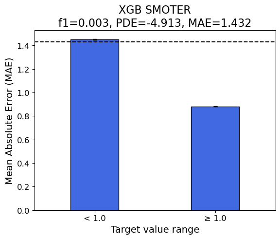

```
MAE: 1.432035163206134
average computational time: 3.70 s
```

```python
# Parameters
overs = ['extreme']
ks = [15] # nearest neighbors
params = list(itertools.product(overs, ks))

# Empty lists for storing results
pdestore, f1store, maebinstore, maestore, timestore = [], [], [], [], []
pdeerrstore, f1errstore, maebinerrstore, maeerrstore, timeerrstore = [], [], [], [], []

# Grid search
for over, k in params:
    kfold = KFold(n_splits=5, shuffle=True, random_state=42)
    pdes, f1s, maebins, maes, times = [], [], [], [], []

    # Fivefold cross validation
    for train_index, test_index in kfold.split(X):
        X_train, y_train = X.loc[train_index,:].reset_index(drop=True), y.loc[train_index].reset_index(drop=True)
        X_test, y_test = X.loc[test_index,:].reset_index(drop=True), y.loc[test_index].reset_index(drop=True)

        # Resample training data (SMOTER)
        relevance = resreg.sigmoid_relevance(y_train, cl=None, ch=bins[0])
        X_train, y_train = resreg.smoter(X_train, y_train, relevance,
                                relevance_threshold=0.5, k=k, over=over, random_state=0)

        # Fit regressor and evaluate performance
        reg = xgb.XGBRegressor(objective='reg:tweedie', tweedie_variance_power=1.8)
        pde, f1, maebin, mae, y_pred, comp_time = implementML(X_train, y_train, X_test, y_test, reg)
        pdes.append(pde)
        f1s.append(f1)
        maebins.append(maebin)
        maes.append(mae)
        times.append(comp_time)
        print('Fold done in:',format(comp_time, '.2f'),'s')

    pde, f1, maebin, mae, comp_time = np.mean(pdes), np.mean(f1s), np.mean(maebins, axis=0), np.mean(maes), np.mean(times)
    pdeerr, f1err, maebinerr, maeerr, comp_timeerr = np.std(pdes)/np.sqrt(5), np.std(f1s)/np.sqrt(5), \
                                np.std(maebins, axis=0)/np.sqrt(5), np.std(maes)/np.sqrt(5), np.std(times)/np.sqrt(5)

    # Store grid search results
    pdestore.append(pde); f1store.append(f1); maebinstore.append(maebin); maestore.append(mae), timestore.append(comp_time)
    pdeerrstore.append(pdeerr); f1errstore.append(f1err); maebinerrstore.append(maebinerr); maeerrstore.append(maeerr); timeerrstore.append(comp_timeerr)

# Determine the best parameters
best = np.argsort(f1store)[-1] # Which is the best
print('''Best parameters:
    over={0}; k={1}'''.format(params[best][0], params[best][1]))
f1, pde, maebin, mae, comp_time = f1store[best], pdestore[best], maebinstore[best], maestore[best], timestore[best]
f1err, pdeerr, maebinerr, maeerr, comp_timeerr = f1errstore[best], pdeerrstore[best], maebinerrstore[best], maeerrstore[best], timeerrstore[best]

# Save results
CACHE['XGB SMOTER'] = [pde, f1, maebin, mae, pdeerr, f1err, maebinerr, maeerr, comp_time, comp_timeerr]

# Plot results
plotPerformance(maebin, maebinerr, f1, pde, mae, title='XGB SMOTER')
print('average computational time:', format(comp_time, '.2f'),'s')
```

### XGB GN

```
Fold done in: 3.47 s
Fold done in: 3.62 s
Fold done in: 3.57 s
Fold done in: 3.62 s
Fold done in: 3.90 s
Best parameters:
    over=extreme; delta=0.1
```

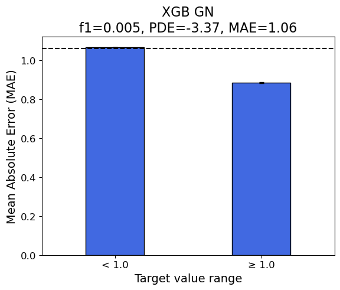

```
MAE: 1.0597004264431535
average computational time: 3.64 s
```

```python
# Parameters
overs = ['extreme']
deltas = [0.1] # amount of Gaussian noise
params = list(itertools.product(overs, deltas))

# Empty lists for storing results
pdestore, f1store, maebinstore, maestore, timestore = [], [], [], [], []
pdeerrstore, f1errstore, maebinerrstore, maeerrstore, timeerrstore = [], [], [], [], []

# Grid search
for over, delta in params:
    kfold = KFold(n_splits=5, shuffle=True, random_state=42)
    pdes, f1s, maebins, maes, times = [], [], [], [], []

    # Fivefold cross validation
    for train_index, test_index in kfold.split(X):
        X_train, y_train = X.loc[train_index,:].reset_index(drop=True), y.loc[train_index].reset_index(drop=True)
        X_test, y_test = X.loc[test_index,:].reset_index(drop=True), y.loc[test_index].reset_index(drop=True)

        # Resample training data (Gaussian Noise)
        relevance = resreg.sigmoid_relevance(y_train, cl=None, ch=bins[0])
        X_train, y_train = resreg.gaussian_noise(X_train, y_train, relevance,
                                relevance_threshold=0.5, delta=delta, over=over,
                                random_state=0)

        # Fit regressor and evaluate performance
        reg = xgb.XGBRegressor(objective='reg:tweedie', tweedie_variance_power=1.8)
        pde, f1, maebin, mae, y_pred, comp_time = implementML(X_train, y_train, X_test, y_test, reg)
        pdes.append(pde)
        f1s.append(f1)
        maebins.append(maebin)
        maes.append(mae)
        times.append(comp_time)
        print('Fold done in:',format(comp_time, '.2f'),'s')

    pde, f1, maebin, mae, comp_time = np.mean(pdes), np.mean(f1s), np.mean(maebins, axis=0), np.mean(maes), np.mean(times)
    pdeerr, f1err, maebinerr, maeerr, comp_timeerr = np.std(pdes)/np.sqrt(5), np.std(f1s)/np.sqrt(5), \
                                np.std(maebins, axis=0)/np.sqrt(5), np.std(maes)/np.sqrt(5), np.std(times)/np.sqrt(5)

    # Store grid search results
    pdestore.append(pde); f1store.append(f1); maebinstore.append(maebin); maestore.append(mae), timestore.append(comp_time)
    pdeerrstore.append(pdeerr); f1errstore.append(f1err); maebinerrstore.append(maebinerr); maeerrstore.append(maeerr); timeerrstore.append(comp_timeerr)


# Determine the best parameters
best = np.argsort(f1store)[-1] # Which is the best
print('''Best parameters:
    over={0}; delta={1}'''.format(params[best][0], params[best][1]))
f1, pde, maebin, mae, comp_time = f1store[best], pdestore[best], maebinstore[best], maestore[best], timestore[best]
f1err, pdeerr, maebinerr, maeerr, comp_timeerr = f1errstore[best], pdeerrstore[best], maebinerrstore[best], maeerrstore[best], timeerrstore[best]

# Save results
CACHE['XGB GN'] = [pde, f1, maebin, mae, pdeerr, f1err, maebinerr, maeerr, comp_time, comp_timeerr]

# Plot results
plotPerformance(maebin, maebinerr, f1, pde, mae, title='XGB GN')
print('average computational time:', format(comp_time, '.2f'),'s')
```

### XGB WERCS

```
Fold done in: 2.78 s
Fold done in: 2.88 s
Fold done in: 3.08 s
Fold done in: 2.97 s
Fold done in: 2.74 s
Best parameters:
    over=1.0; under=0.75; noise=False; delta=None
```

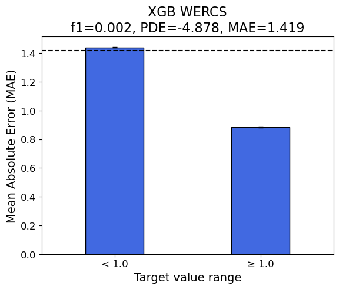

```
MAE: 1.4194653064375515
average computational time: 2.89 s
```

```python
# Parameters
overs = [1.0] # percent of samples added
unders = [0.75] # percent of samples removed
noises = [False] # Whether to add Gaussian noise to oversampled data
params = list(itertools.product(overs, unders, noises))

# Empty lists for storing results
pdestore, f1store, maebinstore, maestore, timestore = [], [], [], [], []
pdeerrstore, f1errstore, maebinerrstore, maerrstore = [], [], [], []

# Grid search
for param in params:
    if len(param)==4:
        over, under, noise, delta = param
    else:
        over, under, noise = param
        delta = None
    kfold = KFold(n_splits=5, shuffle=True, random_state=42)
    pdes, f1s, maebins, maes, times = [], [], [], [], []

    # Fivefold cross validation
    for train_index, test_index in kfold.split(X):
        X_train, y_train = X.loc[train_index,:].reset_index(drop=True), y.loc[train_index].reset_index(drop=True)
        X_test, y_test = X.loc[test_index,:].reset_index(drop=True), y.loc[test_index].reset_index(drop=True)

        # Resample training data (WERCS)
        relevance = resreg.sigmoid_relevance(y_train, cl=None, ch=bins[0])
        X_train, y_train = resreg.wercs(X_train, y_train, relevance, over=over,
                              under=under, noise=noise, delta=delta, random_state=0)

        # Fit regressor and evaluate performance
        reg = xgb.XGBRegressor(objective='reg:tweedie', tweedie_variance_power=1.8)
        pde, f1, maebin, mae, y_pred, comp_time = implementML(X_train, y_train, X_test, y_test, reg)
        pdes.append(pde)
        f1s.append(f1)
        maebins.append(maebin)
        maes.append(mae)
        times.append(comp_time)
        print('Fold done in:',format(comp_time, '.2f'),'s')

    pde, f1, maebin, mae, comp_time = np.mean(pdes), np.mean(f1s), np.mean(maebins, axis=0), np.mean(maes), np.mean(times)
    pdeerr, f1err, maebinerr, maeerr, comp_timeerr = np.std(pdes)/np.sqrt(5), np.std(f1s)/np.sqrt(5), \
                                np.std(maebins, axis=0)/np.sqrt(5), np.std(maes)/np.sqrt(5), np.std(times)/np.sqrt(5)

    # Store grid search results
    pdestore.append(pde); f1store.append(f1); maebinstore.append(maebin); maestore.append(mae), timestore.append(comp_time)
    pdeerrstore.append(pdeerr); f1errstore.append(f1err); maebinerrstore.append(maebinerr); maeerrstore.append(maeerr); timeerrstore.append(comp_timeerr)

# Determine the best parameters
best = np.argsort(f1store)[-1] # Which is the best
bestparam = params[best]
if len(param)==4:
    over, under, noise, delta= param
else:
    over, under, noise = param
    delta = None
print(f'''Best parameters:
    over={over}; under={under}; noise={noise}; delta={delta}''')
f1, pde, maebin, mae, comp_time = f1store[best], pdestore[best], maebinstore[best], maestore[best], timestore[best]
f1err, pdeerr, maebinerr, maeerr, comp_timeerr = f1errstore[best], pdeerrstore[best], maebinerrstore[best], maeerrstore[best], timeerrstore[best]

# Save results
CACHE['XGB WERCS'] = [pde, f1, maebin, mae, pdeerr, f1err, maebinerr, maeerr, comp_time, comp_timeerr]

# Plot results
plotPerformance(maebin, maebinerr, f1, pde, mae, title='XGB WERCS')
print('average computational time:', format(comp_time, '.2f'),'s')
```

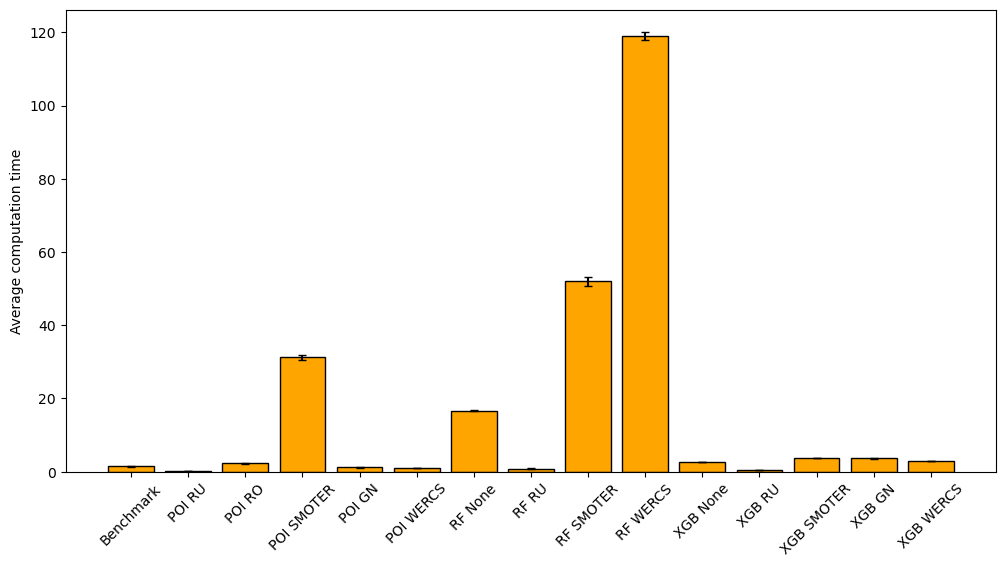

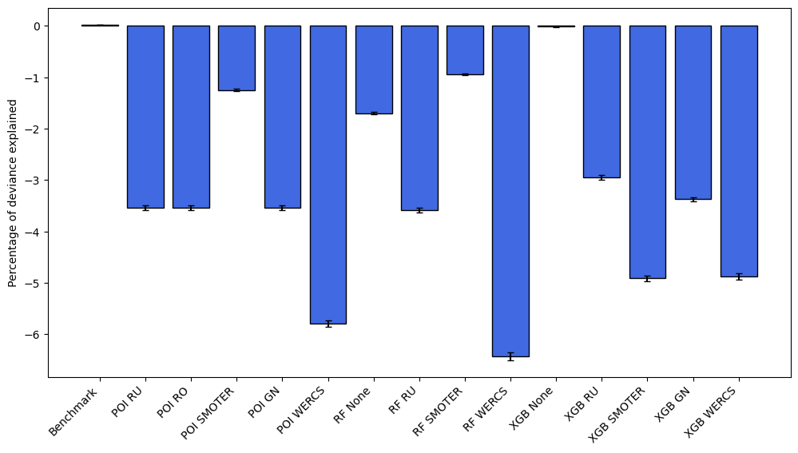

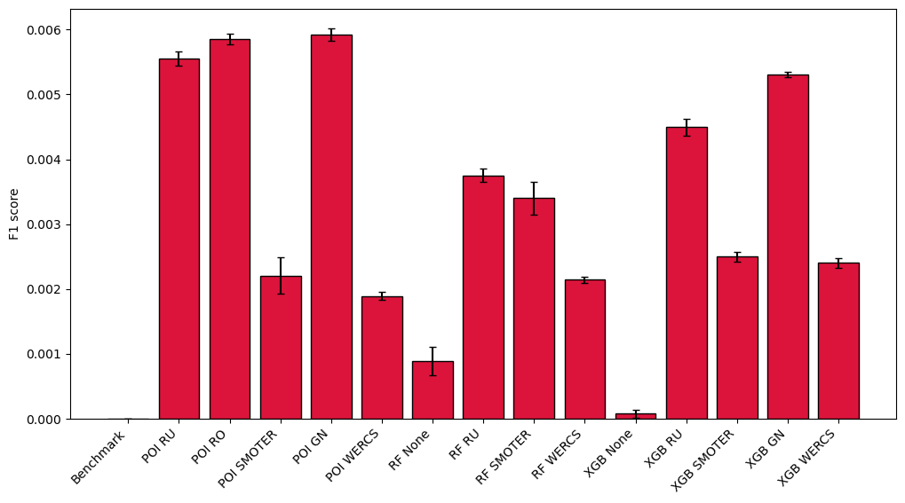

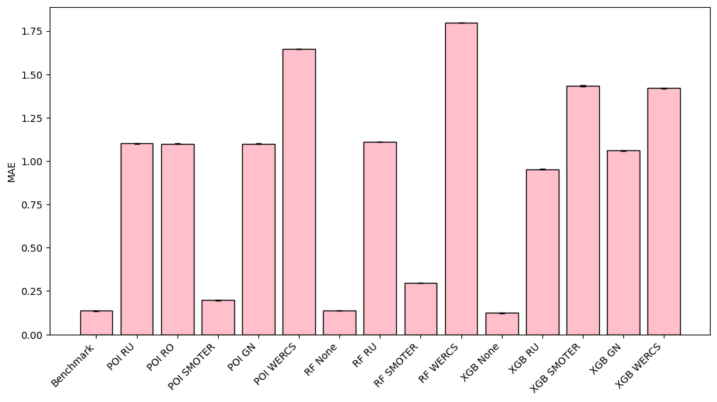

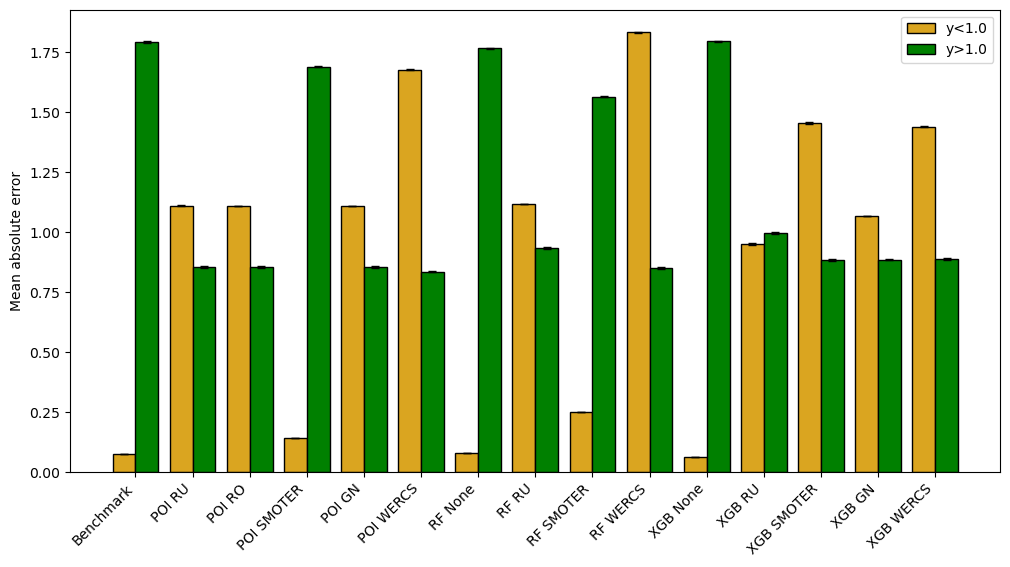

```python
# Data from CACHE
pdes = [val[0] for val in CACHE.values()]
pdeerrs = [val[4] for val in CACHE.values()]
f1s = [val[1] for val in CACHE.values()]
f1errs = [val[5] for val in CACHE.values()]
maebins = np.asarray([val[2] for val in CACHE.values()])
maebinerrs = np.asarray([val[6] for val in CACHE.values()])
maes = [val[3] for val in CACHE.values()]
maeerrs = [val[7] for val in CACHE.values()]
times = [val[8] for val in CACHE.values()]
timeerrs = [val[9] for val in CACHE.values()]
keys = CACHE.keys()

# Plot time
plt.figure(figsize=(12,6))
plt.bar(range(len(keys)), times, yerr=timeerrs, capsize=3, color='orange',
       linewidth=1, edgecolor='black')
_ = plt.xticks(range(len(keys)), keys, rotation=45)
plt.ylabel('Average computation time')
plt.show()

# Plot pde
plt.figure(figsize=(12,6))
plt.bar(range(len(keys)), pdes, yerr=pdeerrs, capsize=3, color='royalblue',
       linewidth=1, edgecolor='black', )
_ = plt.xticks(range(len(keys)), keys, rotation=45, ha='right')
plt.ylabel('Percentage of deviance explained')
plt.show()

# Plot F1
plt.figure(figsize=(12,6))
plt.bar(range(len(keys)), f1s, yerr=f1errs, capsize=3, color='crimson',
       linewidth=1, edgecolor='black')
_ = plt.xticks(range(len(keys)), keys, rotation=45, ha='right')
plt.ylabel('F1 score')
plt.show()

# Plot MAE
plt.figure(figsize=(12,6))
plt.bar(range(len(keys)), maes, yerr=maeerrs, capsize=3, color='pink',
       linewidth=1, edgecolor='black')
_ = plt.xticks(range(len(keys)), keys, rotation=45, ha='right')
plt.ylabel('MAE')
plt.show()

# Plot MAE over bins
plt.figure(figsize=(12,6))
plt.bar(np.arange(len(keys))-0.2, maebins[:,0], width=0.4, yerr=maebinerrs[:,0],
       capsize=3, color='goldenrod', linewidth=1, edgecolor='black', label='y<1.0')
plt.bar(np.arange(len(keys))+0.2, maebins[:,1], width=0.4, yerr=maebinerrs[:,1],
       capsize=3, color='green', linewidth=1, edgecolor='black', label='y>1.0')
_ = plt.xticks(range(len(keys)), keys, rotation=45, ha='right')
plt.ylabel('Mean absolute error')
plt.legend()
plt.show()
```

```python
joblib.dump(CACHE, 'cache.pkl')
```

```
['cache.pkl']
```

### Steps in the REBAGG algorithm

1. For each of ${m}$ base learners, ${s}$ samples are drawn from the training dataset.
2. If *size_method* is *balance*, then equal number of samples (${s}$/2) are randomly drawn from the rare and normal domains. Otherwise, if *size_method* is *variation*, ${s \times p}$ and ${s \times (1-p)}$ samples are randomly drawn from the rare and normal domains, respectively. ${p}$ is randomly chosen from (1/3, 2/5, 1/2, 2/5, 2/3).
3. If the rare domain is smaller than ${s}$/2 (or ${s \times p}$, if *size_method* is *variation*), then the rare domain is oversampled using a selected *sample_method* (random oversampling, SMOTER, or Gaussian noise) before drawing samples.
4. Alternatively, if *sample_method* is *wercs*, the relevance values are used as weights to resample the dataset before selecting ${s}$ samples for fitting ${m}$ base learners.
5. The ${m}$ base learners are fitted on the resampled datasets.
6. Each base learner is applied to the test data and the average of the ${m}$ predictions is returned as the final output.

### REBAGG with random oversampling (REBAGG-RO)

The rare domain is oversampled by duplicating randomly selected values before fitting base learners. We will determine the best hyperparameters by a grid search.

```python
# Hyperparameters
sizes = [0.5]  # size of bootstrap sample as a fraction of total size
size_methods = ['balance'] # whether to select equal samples from rare and normal domains
params = list(itertools.product(sizes, size_methods))

# Grid search
pdestore, f1store, maebinstore, maestore, timestore = [], [], [], [], [] # Empty lists for storing results
pdeerrstore, f1errstore, maebinerrstore, maeerrstore, timeerrstore = [], [], [], [], []

for param in params:
    s, size_method = param

    # Fivefold cross validation (fit ensemble and evaluate performance on test set)
    kfold = KFold(n_splits=5, shuffle=True, random_state=42)
    pdes, f1s, maebins, maes, times = [], [], [], [], []# Empty lists to store results
    for train_index, test_index in kfold.split(X):
        X_train, y_train = X.loc[train_index,:].reset_index(drop=True), y.loc[train_index].reset_index(drop=True)
        X_test, y_test = X.loc[test_index,:].reset_index(drop=True), y.loc[test_index].reset_index(drop=True)
        relevance = resreg.sigmoid_relevance(y_train, cl=None, ch=bins[0]) # right-sided relevance function

        # Fit rebagg ensemble using random oversampling to oversample the rare domain
        reg = DecisionTreeRegressor(max_features=0.5, random_state=0)  # base learner
        rebagg = resreg.Rebagg(m=50, s=s, base_reg=reg) # create a rebagg instance
        start_time = time.time() # Measure computation time
        rebagg.fit(X_train, y_train, relevance=relevance, relevance_threshold=0.5,
                   sample_method='random_oversample', size_method=size_method, random_state=0)

        # Evaluate performance on testing set
        y_pred = rebagg.predict(X_test)
        end_time = time.time()
        comp_time = end_time - start_time
        d = mean_poisson_deviance(y_test, y_pred+1e-9)
        d0 = mean_poisson_deviance(y_test, np.repeat(np.mean(y_test), len(y_test)))
        pde = 1 - d/d0
        rel_test = resreg.sigmoid_relevance(y_test, cl=None, ch=bins[0]) # relevance values of y_test
        rel_pred = resreg.sigmoid_relevance(y_pred, cl=None, ch=bins[0]) # relevance values of y_pred
        f1 = resreg.f1_score(y_test, y_pred, error_threshold=0.05, relevance_true=rel_test,
                            relevance_pred=rel_pred, relevance_threshold=0.5)
        maebin = resreg.bin_performance(y_test, y_pred, bins=bins, metric='mae')
        mae = mean_absolute_error(y_test, y_pred)
        pdes.append(pde); f1s.append(f1); maebins.append(maebin); maes.append(mae); times.append(comp_time)
        print('Fold done in:',format(comp_time, '.2f'),'s')

    # Average performance over fivefold cross validation
    pde, f1, maebin, mae, comp_time = np.mean(pdes), np.mean(f1s), np.mean(maebins, axis=0), np.mean(maes), np.mean(times)
    pdeerr, f1err, maebinerr, maeerr, comp_timeerr = np.std(pdes)/np.sqrt(5), np.std(f1s)/np.sqrt(5), \
                                np.std(maebins, axis=0)/np.sqrt(5), np.std(maes)/np.sqrt(5), np.std(times)/np.sqrt(5) # standard error
    # Save grid search results
    pdestore.append(pde); f1store.append(f1); maebinstore.append(maebin); maestore.append(mae), timestore.append(comp_time)
    pdeerrstore.append(pdeerr); f1errstore.append(f1err); maebinerrstore.append(maebinerr); maeerrstore.append(maeerr); timeerrstore.append(comp_timeerr)
```

```
Fold done in: 44.20 s
Fold done in: 44.10 s
Fold done in: 43.72 s
Fold done in: 43.72 s
Fold done in: 43.38 s
```

**View performance of best hyperparameters**

```
Best parameters:
      s=0.5, size_method=balance
```

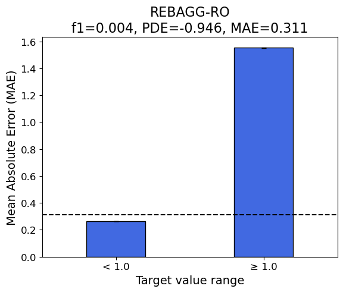

```
MAE: 0.31092919882443565
average computational time: 43.82 s
```

```python
# Best hyperparameters
best = np.argsort(f1store)[-1] # Which is the best
bestparams = params[best]
print(f'''Best parameters:
      s={bestparams[0]}, size_method={bestparams[1]}''')
f1, pde, maebin, mae, comp_time = f1store[best], pdestore[best], maebinstore[best], maestore[best], timestore[best]
f1err, pdeerr, maebinerr, maeerr, comp_timeerr = f1errstore[best], pdeerrstore[best], maebinerrstore[best], maeerrstore[best], timeerrstore[best]

# Plot results
ticks_font = {'size':'12'}
label_font = {'size':'14'}
title_font = {'size':'16'}

def plotPerformance(maebin, maebinerr, f1, pde, mae, title):
    plt.bar(range(2), maebin, yerr=maebinerr, width=0.4, capsize=3, color='royalblue',
           linewidth=1, edgecolor='black')
    plt.axhline(mae, color='black', linestyle='--')
    plt.xlim(-0.5, len(bins)+0.5)
    plt.xticks(range(2), ['< {0}'.format(bins[0]), '≥ {0}'.format(bins[0])], **ticks_font)
    plt.yticks(**ticks_font)
    plt.ylabel('Mean Absolute Error (MAE)', **label_font)
    plt.xlabel('Target value range', **label_font)
    title = title + '\nf1={0}, PDE={1}, MAE={2}'.format(round(f1,3), round(pde,3), round(mae,3))
    plt.title(title, **title_font)
    plt.show()
    plt.close()
    print('MAE:', mae)

plotPerformance(maebin, maebinerr, f1, pde, mae, title='REBAGG-RO')
print('average computational time:', format(comp_time, '.2f'),'s')

# Save results
CACHE = joblib.load('cache.pkl')
CACHE['REBAGG-RO'] = [pde, f1, maebin, mae, pdeerr, f1err, maebinerr, maeerr, comp_time, comp_timeerr]
```

### REBAGG with WERCS (REBAGG-WERCS)

The data is resampled with the WERCS method (sampled using the relevance as weights), before fitting each base learner. Gaussian noise may be added to the resampled data by specifying *sample_method* as *wercs-gn*.

```python
# Hyperparameters
sizes = [0.5]
overs = [0.25]
unders = [0.25]

params = list(itertools.product(sizes, overs, unders))

# Grid search
pdestore, f1store, maebinstore, maestore, timestore = [], [], [], [], []  # Empty lists for storing results
pdeerrstore, f1errstore, maebinerrstore, maeerrstore, timeerrstore = [], [], [], [], []

for param in params:
    if len(param) == 3:
        sample_method = 'wercs' # wercs without gaussian noise
        s, over, under = param
    else:
        sample_method = 'wercs-gn'  # wercs with gaussian noise
        s, over, under, delta = param

    # Fivefold cross valdation (fit ensemble and evaluate performance on testing set)
    kfold = KFold(n_splits=5, shuffle=True, random_state=42)
    pdes, f1s, maebins, maes, times = [], [], [], [], [] # Empty lists to store results
    for train_index, test_index in kfold.split(X):
        X_train, y_train = X.loc[train_index,:].reset_index(drop=True), y.loc[train_index].reset_index(drop=True)
        X_test, y_test = X.loc[test_index,:].reset_index(drop=True), y.loc[test_index].reset_index(drop=True)
        relevance = resreg.sigmoid_relevance(y_train, cl=None, ch=bins[0])

        # Fit Rebagg ensemble
        reg = DecisionTreeRegressor(max_features=0.5, random_state=0) # base learner
        rebagg = resreg.Rebagg(m=50, s=s, base_reg=reg)
        start_time = time.time() # Measure computation time
        rebagg.fit(X_train, y_train, relevance=relevance, sample_method=sample_method,
                   over=over, under=under, delta=delta, random_state=0)

        # Evaluate performance on testing set
        y_pred = rebagg.predict(X_test)
        end_time = time.time()
        comp_time = end_time - start_time
        d = mean_poisson_deviance(y_test, y_pred+1e-9)
        d0 = mean_poisson_deviance(y_test, np.repeat(np.mean(y_test), len(y_test)))
        pde = 1 - d/d0
        relTrue = resreg.sigmoid_relevance(y_test, cl=None, ch=bins[0])
        relPred = resreg.sigmoid_relevance(y_pred, cl=None, ch=bins[0])
        f1 = resreg.f1_score(y_test, y_pred, error_threshold=0.05, relevance_true=relTrue,
                             relevance_pred=relPred, relevance_threshold=0.5)
        maebin = resreg.bin_performance(y_test, y_pred, bins=bins, metric='mae')
        mae = mean_absolute_error(y_test, y_pred)
        pdes.append(pde); f1s.append(f1); maebins.append(maebin); maes.append(mae); times.append(comp_time)
        print('Fold done in:',format(comp_time, '.2f'),'s')

    # Average performance over fivefold cross validation
    pde, f1, maebin, mae = np.mean(pdes), np.mean(f1s), np.mean(maebins, axis=0), np.mean(mae)
    pdeerr, f1err, maebinerr, maeerr, comp_timeerr = np.std(pdes)/np.sqrt(5), np.std(f1s)/np.sqrt(5), \
                            np.std(maebins, axis=0)/np.sqrt(5), np.std(maes)/np.sqrt(5), np.std(times)/np.sqrt(5)  # standard error

    # Save grid search results
    pdestore.append(pde); f1store.append(f1); maebinstore.append(maebin); maestore.append(mae), timestore.append(comp_time)
    pdeerrstore.append(pdeerr); f1errstore.append(f1err); maebinerrstore.append(maebinerr); maeerrstore.append(maeerr); timeerrstore.append(comp_timeerr)
```

```
Fold done in: 57.92 s
Fold done in: 57.71 s
Fold done in: 58.59 s
Fold done in: 58.55 s
Fold done in: 58.97 s
```

**View performance of best hyperparameters**

```
Best parameters:
      s=0.5, over=0.25, under=0.25
```

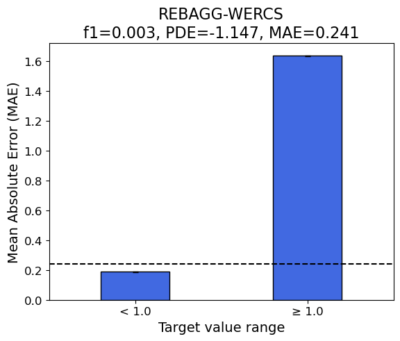

```
MAE: 0.24051931612829316
average computational time: 58.97 s
```

```python
# Best hyperparameters
best = np.argsort(f1store)[-1] # Which is the best
bestparams = params[best]
if len(bestparams)==4:
    print(f'''Best parameters:
      s={bestparams[0]}, over={bestparams[1]}, under={bestparams[2]}, delta={bestparams[3]}''')
else:
    print(f'''Best parameters:
      s={bestparams[0]}, over={bestparams[1]}, under={bestparams[2]}''')

f1, pde, maebin, mae, comp_time = f1store[best], pdestore[best], maebinstore[best], maestore[best], timestore[best]
f1err, pdeerr, maebinerr, maeerr, comp_timeerr = f1errstore[best], pdeerrstore[best], maebinerrstore[best], maeerrstore[best], timeerrstore[best]

# Plot results
plotPerformance(maebin, maebinerr, f1, pde, mae, title='REBAGG-WERCS')
print('average computational time:', format(comp_time, '.2f'),'s')

# Save results
CACHE['REBAGG-WERCS'] = [pde, f1, maebin, mae, pdeerr, f1err, maebinerr, maeerr, comp_time, comp_timeerr]
```